# Risk Factor Analysis

## Outcome Variable

**Outcome Variable:** wast_rec90d

## Predictor Variables

**Intervention Variable:** hfoodsec

**Adjustment Set:**

- arm
- sex
- W_mage
- meducyrs
- feducyrs
- hhwealth_quart
- vagbrth
- W_nrooms
- W_nchldlt5
- brthmon
- W_parity
- impfloor
- impsan
- safeh20
- delta_W_mage
- delta_meducyrs
- delta_feducyrs
- delta_hhwealth_quart
- delta_vagbrth
- delta_W_nrooms
- delta_W_nchldlt5
- delta_brthmon
- delta_W_parity
- delta_impfloor
- delta_impsan
- delta_safeh20

## Stratifying Variables

The analysis was stratified on these variable(s):

- agecat
- studyid
- country

## Data Summary

| agecat | studyid | country | hfoodsec | wast_rec90d | n_cell | n |
| --- | --- | --- | --- | --- | --- | --- |
| 0-24 months | GMS-Nepal | NEPAL | Food Secure | 0 | 201 | 624 |
| 0-24 months | GMS-Nepal | NEPAL | Food Secure | 1 | 251 | 624 |
| 0-24 months | GMS-Nepal | NEPAL | Mildly Food Insecure | 0 | 37 | 624 |
| 0-24 months | GMS-Nepal | NEPAL | Mildly Food Insecure | 1 | 42 | 624 |
| 0-24 months | GMS-Nepal | NEPAL | Food Insecure | 0 | 46 | 624 |
| 0-24 months | GMS-Nepal | NEPAL | Food Insecure | 1 | 47 | 624 |
| 0-24 months | JiVitA-3 | BANGLADESH | Food Secure | 0 | 1604 | 5644 |
| 0-24 months | JiVitA-3 | BANGLADESH | Food Secure | 1 | 1031 | 5644 |
| 0-24 months | JiVitA-3 | BANGLADESH | Mildly Food Insecure | 0 | 1185 | 5644 |
| 0-24 months | JiVitA-3 | BANGLADESH | Mildly Food Insecure | 1 | 714 | 5644 |
| 0-24 months | JiVitA-3 | BANGLADESH | Food Insecure | 0 | 729 | 5644 |
| 0-24 months | JiVitA-3 | BANGLADESH | Food Insecure | 1 | 381 | 5644 |
| 0-24 months | JiVitA-4 | BANGLADESH | Food Secure | 0 | 763 | 2053 |
| 0-24 months | JiVitA-4 | BANGLADESH | Food Secure | 1 | 265 | 2053 |
| 0-24 months | JiVitA-4 | BANGLADESH | Mildly Food Insecure | 0 | 561 | 2053 |
| 0-24 months | JiVitA-4 | BANGLADESH | Mildly Food Insecure | 1 | 204 | 2053 |
| 0-24 months | JiVitA-4 | BANGLADESH | Food Insecure | 0 | 200 | 2053 |
| 0-24 months | JiVitA-4 | BANGLADESH | Food Insecure | 1 | 60 | 2053 |
| 0-24 months | MAL-ED | BANGLADESH | Food Secure | 0 | 31 | 100 |
| 0-24 months | MAL-ED | BANGLADESH | Food Secure | 1 | 49 | 100 |
| 0-24 months | MAL-ED | BANGLADESH | Mildly Food Insecure | 0 | 1 | 100 |
| 0-24 months | MAL-ED | BANGLADESH | Mildly Food Insecure | 1 | 2 | 100 |
| 0-24 months | MAL-ED | BANGLADESH | Food Insecure | 0 | 6 | 100 |
| 0-24 months | MAL-ED | BANGLADESH | Food Insecure | 1 | 11 | 100 |
| 0-24 months | MAL-ED | BRAZIL | Food Secure | 0 | 0 | 15 |
| 0-24 months | MAL-ED | BRAZIL | Food Secure | 1 | 0 | 15 |
| 0-24 months | MAL-ED | BRAZIL | Mildly Food Insecure | 0 | 0 | 15 |
| 0-24 months | MAL-ED | BRAZIL | Mildly Food Insecure | 1 | 0 | 15 |
| 0-24 months | MAL-ED | BRAZIL | Food Insecure | 0 | 3 | 15 |
| 0-24 months | MAL-ED | BRAZIL | Food Insecure | 1 | 12 | 15 |

[output cut: 168 more lines]

The following strata were considered:

- agecat: 0-24 months, studyid: GMS-Nepal, country: NEPAL
- agecat: 0-24 months, studyid: JiVitA-3, country: BANGLADESH
- agecat: 0-24 months, studyid: JiVitA-4, country: BANGLADESH
- agecat: 0-24 months, studyid: MAL-ED, country: BANGLADESH
- agecat: 0-24 months, studyid: MAL-ED, country: BRAZIL
- agecat: 0-24 months, studyid: MAL-ED, country: INDIA
- agecat: 0-24 months, studyid: MAL-ED, country: NEPAL
- agecat: 0-24 months, studyid: MAL-ED, country: PERU
- agecat: 0-24 months, studyid: MAL-ED, country: SOUTH AFRICA
- agecat: 0-24 months, studyid: NIH-Birth, country: BANGLADESH
- agecat: 0-24 months, studyid: NIH-Crypto, country: BANGLADESH
- agecat: 0-6 months, studyid: GMS-Nepal, country: NEPAL
- agecat: 0-6 months, studyid: JiVitA-3, country: BANGLADESH
- agecat: 0-6 months, studyid: JiVitA-4, country: BANGLADESH
- agecat: 0-6 months, studyid: MAL-ED, country: BANGLADESH
- agecat: 0-6 months, studyid: MAL-ED, country: BRAZIL
- agecat: 0-6 months, studyid: MAL-ED, country: INDIA
- agecat: 0-6 months, studyid: MAL-ED, country: NEPAL
- agecat: 0-6 months, studyid: MAL-ED, country: PERU
- agecat: 0-6 months, studyid: MAL-ED, country: SOUTH AFRICA
- agecat: 0-6 months, studyid: NIH-Birth, country: BANGLADESH
- agecat: 0-6 months, studyid: NIH-Crypto, country: BANGLADESH
- agecat: 6-24 months, studyid: GMS-Nepal, country: NEPAL
- agecat: 6-24 months, studyid: JiVitA-3, country: BANGLADESH
- agecat: 6-24 months, studyid: JiVitA-4, country: BANGLADESH
- agecat: 6-24 months, studyid: MAL-ED, country: BANGLADESH
- agecat: 6-24 months, studyid: MAL-ED, country: BRAZIL
- agecat: 6-24 months, studyid: MAL-ED, country: INDIA
- agecat: 6-24 months, studyid: MAL-ED, country: NEPAL
- agecat: 6-24 months, studyid: MAL-ED, country: PERU
- agecat: 6-24 months, studyid: MAL-ED, country: SOUTH AFRICA
- agecat: 6-24 months, studyid: NIH-Birth, country: BANGLADESH
- agecat: 6-24 months, studyid: NIH-Crypto, country: BANGLADESH

### Dropped Strata

Some strata were dropped due to rare outcomes:

- agecat: 0-24 months, studyid: MAL-ED, country: BANGLADESH
- agecat: 0-24 months, studyid: MAL-ED, country: BRAZIL
- agecat: 0-24 months, studyid: MAL-ED, country: INDIA
- agecat: 0-24 months, studyid: MAL-ED, country: NEPAL
- agecat: 0-24 months, studyid: MAL-ED, country: PERU
- agecat: 0-24 months, studyid: MAL-ED, country: SOUTH AFRICA
- agecat: 0-6 months, studyid: MAL-ED, country: BANGLADESH
- agecat: 0-6 months, studyid: MAL-ED, country: BRAZIL
- agecat: 0-6 months, studyid: MAL-ED, country: INDIA
- agecat: 0-6 months, studyid: MAL-ED, country: NEPAL
- agecat: 0-6 months, studyid: MAL-ED, country: PERU
- agecat: 0-6 months, studyid: MAL-ED, country: SOUTH AFRICA
- agecat: 0-6 months, studyid: NIH-Crypto, country: BANGLADESH
- agecat: 6-24 months, studyid: JiVitA-3, country: BANGLADESH
- agecat: 6-24 months, studyid: MAL-ED, country: BANGLADESH
- agecat: 6-24 months, studyid: MAL-ED, country: BRAZIL
- agecat: 6-24 months, studyid: MAL-ED, country: INDIA
- agecat: 6-24 months, studyid: MAL-ED, country: NEPAL
- agecat: 6-24 months, studyid: MAL-ED, country: PERU
- agecat: 6-24 months, studyid: MAL-ED, country: SOUTH AFRICA
- agecat: 6-24 months, studyid: NIH-Birth, country: BANGLADESH
- agecat: 6-24 months, studyid: NIH-Crypto, country: BANGLADESH

## Methods Detail

We’re interested in the causal parameters $E[Y_a]$ for all values of $a \in \mathcal{A}$. These parameters represent the mean outcome if, possibly contrary to fact, we intervened to set all units to have $A=a$. Under the randomization and positivity assumptions, these are identified by the statistical parameters $\psi_a=E_W[E_{Y|A,W}(Y|A=a,W)]$. In addition, we’re interested in the mean of $Y$, $E[Y]$ under no intervention (the observed mean). We will estimate these parameters by using SuperLearner to fit the relevant likelihood factors – $E_{Y|A,W}(Y|A=a,W)$ and $p(A=a|W)$, and then updating our likelihood fit using a joint TMLE.

For unadjusted analyses ($W=\{\}$), initial likelihoods were estimated using Lrnr_glm to estimate the simple $E(Y|A)$ and Lrnr_mean to estimate $p(A)$. For adjusted analyses, a small library containing Lrnr_glmnet, Lrnr_xgboost, and Lrnr_mean was used.

Having estimated these parameters, we will then use the delta method to estimate relative risks and attributable risks relative to a prespecified baseline level of $A$.

# Results Detail

## Results Plots

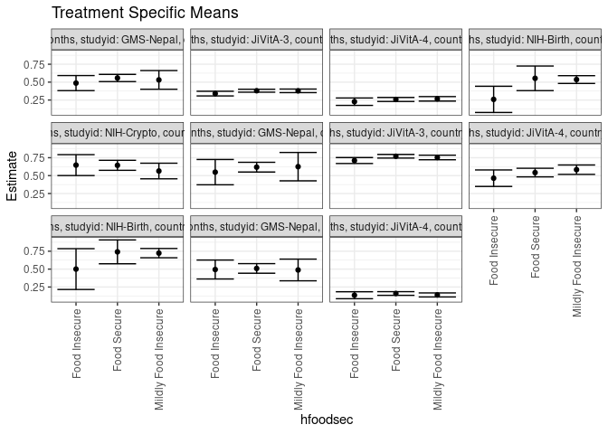

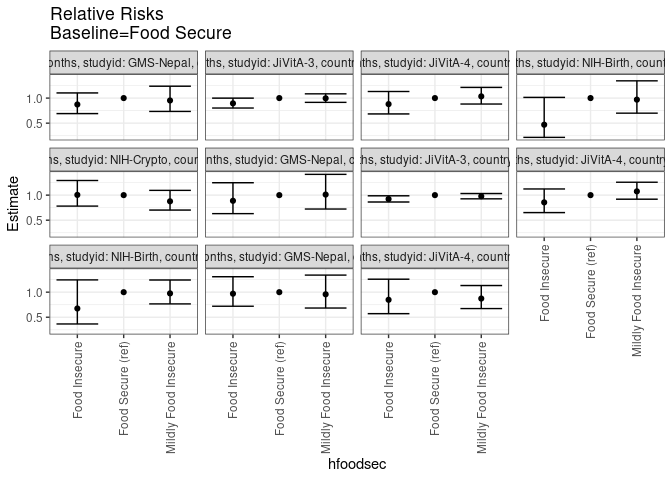

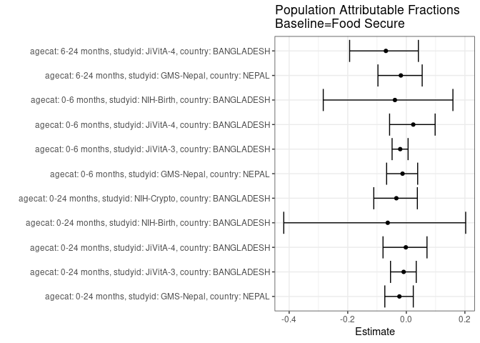

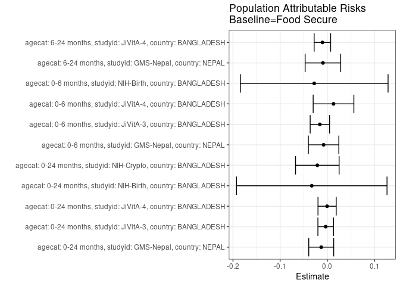

## Results Table

### Parameter: TSM

| agecat | studyid | country | intervention_level | baseline_level | estimate | ci_lower | ci_upper |
| --- | --- | --- | --- | --- | --- | --- | --- |
| 0-24 months | GMS-Nepal | NEPAL | Food Secure | NA | 0.5577457 | 0.5074023 | 0.6080890 |
| 0-24 months | GMS-Nepal | NEPAL | Mildly Food Insecure | NA | 0.5311900 | 0.4009058 | 0.6614742 |
| 0-24 months | GMS-Nepal | NEPAL | Food Insecure | NA | 0.4865788 | 0.3813671 | 0.5917905 |
| 0-24 months | JiVitA-3 | BANGLADESH | Food Secure | NA | 0.3801037 | 0.3592484 | 0.4009590 |
| 0-24 months | JiVitA-3 | BANGLADESH | Mildly Food Insecure | NA | 0.3783986 | 0.3536096 | 0.4031875 |
| 0-24 months | JiVitA-3 | BANGLADESH | Food Insecure | NA | 0.3400390 | 0.3075743 | 0.3725038 |
| 0-24 months | JiVitA-4 | BANGLADESH | Food Secure | NA | 0.2580987 | 0.2301789 | 0.2860186 |
| 0-24 months | JiVitA-4 | BANGLADESH | Mildly Food Insecure | NA | 0.2668722 | 0.2353998 | 0.2983446 |
| 0-24 months | JiVitA-4 | BANGLADESH | Food Insecure | NA | 0.2270008 | 0.1753782 | 0.2786233 |
| 0-24 months | NIH-Birth | BANGLADESH | Food Secure | NA | 0.5531915 | 0.3813656 | 0.7250173 |
| 0-24 months | NIH-Birth | BANGLADESH | Mildly Food Insecure | NA | 0.5360231 | 0.4817521 | 0.5902940 |
| 0-24 months | NIH-Birth | BANGLADESH | Food Insecure | NA | 0.2592593 | 0.0762417 | 0.4422768 |
| 0-24 months | NIH-Crypto | BANGLADESH | Food Secure | NA | 0.6437457 | 0.5738405 | 0.7136509 |
| 0-24 months | NIH-Crypto | BANGLADESH | Mildly Food Insecure | NA | 0.5642860 | 0.4553354 | 0.6732366 |
| 0-24 months | NIH-Crypto | BANGLADESH | Food Insecure | NA | 0.6465400 | 0.5004969 | 0.7925831 |
| 0-6 months | GMS-Nepal | NEPAL | Food Secure | NA | 0.6180905 | 0.5500694 | 0.6861115 |
| 0-6 months | GMS-Nepal | NEPAL | Mildly Food Insecure | NA | 0.6250000 | 0.4270268 | 0.8229732 |
| 0-6 months | GMS-Nepal | NEPAL | Food Insecure | NA | 0.5483871 | 0.3717297 | 0.7250445 |
| 0-6 months | JiVitA-3 | BANGLADESH | Food Secure | NA | 0.7701893 | 0.7446031 | 0.7957755 |
| 0-6 months | JiVitA-3 | BANGLADESH | Mildly Food Insecure | NA | 0.7530596 | 0.7210751 | 0.7850441 |
| 0-6 months | JiVitA-3 | BANGLADESH | Food Insecure | NA | 0.7106451 | 0.6692668 | 0.7520235 |
| 0-6 months | JiVitA-4 | BANGLADESH | Food Secure | NA | 0.5423757 | 0.4823264 | 0.6024250 |
| 0-6 months | JiVitA-4 | BANGLADESH | Mildly Food Insecure | NA | 0.5830337 | 0.5176351 | 0.6484324 |
| 0-6 months | JiVitA-4 | BANGLADESH | Food Insecure | NA | 0.4640004 | 0.3488036 | 0.5791972 |
| 0-6 months | NIH-Birth | BANGLADESH | Food Secure | NA | 0.7407407 | 0.5743234 | 0.9071581 |
| 0-6 months | NIH-Birth | BANGLADESH | Mildly Food Insecure | NA | 0.7228261 | 0.6582010 | 0.7874512 |
| 0-6 months | NIH-Birth | BANGLADESH | Food Insecure | NA | 0.5000000 | 0.2151871 | 0.7848129 |
| 6-24 months | GMS-Nepal | NEPAL | Food Secure | NA | 0.5092771 | 0.4421969 | 0.5763573 |
| 6-24 months | GMS-Nepal | NEPAL | Mildly Food Insecure | NA | 0.4877426 | 0.3362840 | 0.6392012 |
| 6-24 months | GMS-Nepal | NEPAL | Food Insecure | NA | 0.4940334 | 0.3616899 | 0.6263769 |
| 6-24 months | JiVitA-4 | BANGLADESH | Food Secure | NA | 0.1593238 | 0.1335910 | 0.1850566 |
| 6-24 months | JiVitA-4 | BANGLADESH | Mildly Food Insecure | NA | 0.1391164 | 0.1108343 | 0.1673985 |
| 6-24 months | JiVitA-4 | BANGLADESH | Food Insecure | NA | 0.1351362 | 0.0864750 | 0.1837974 |

### Parameter: E(Y)

| agecat | studyid | country | intervention_level | baseline_level | estimate | ci_lower | ci_upper |
| --- | --- | --- | --- | --- | --- | --- | --- |
| 0-24 months | GMS-Nepal | NEPAL | NA | NA | 0.5448718 | 0.5019351 | 0.5878085 |
| 0-24 months | JiVitA-3 | BANGLADESH | NA | NA | 0.3766832 | 0.3641564 | 0.3892100 |
| 0-24 months | JiVitA-4 | BANGLADESH | NA | NA | 0.2576717 | 0.2382743 | 0.2770691 |
| 0-24 months | NIH-Birth | BANGLADESH | NA | NA | 0.5201900 | 0.4695846 | 0.5707955 |
| 0-24 months | NIH-Crypto | BANGLADESH | NA | NA | 0.6225806 | 0.5684562 | 0.6767051 |
| 0-6 months | GMS-Nepal | NEPAL | NA | NA | 0.6102362 | 0.5496896 | 0.6707828 |
| 0-6 months | JiVitA-3 | BANGLADESH | NA | NA | 0.7544358 | 0.7385442 | 0.7703274 |
| 0-6 months | JiVitA-4 | BANGLADESH | NA | NA | 0.5555556 | 0.5139520 | 0.5971591 |
| 0-6 months | NIH-Birth | BANGLADESH | NA | NA | 0.7130045 | 0.6535890 | 0.7724200 |
| 6-24 months | GMS-Nepal | NEPAL | NA | NA | 0.5000000 | 0.4445928 | 0.5554072 |
| 6-24 months | JiVitA-4 | BANGLADESH | NA | NA | 0.1489362 | 0.1312684 | 0.1666040 |

### Parameter: RR

| agecat | studyid | country | intervention_level | baseline_level | estimate | ci_lower | ci_upper |
| --- | --- | --- | --- | --- | --- | --- | --- |
| 0-24 months | GMS-Nepal | NEPAL | Food Secure | Food Secure | 1.0000000 | 1.0000000 | 1.0000000 |
| 0-24 months | GMS-Nepal | NEPAL | Mildly Food Insecure | Food Secure | 0.9523875 | 0.7333657 | 1.2368209 |
| 0-24 months | GMS-Nepal | NEPAL | Food Insecure | Food Secure | 0.8724027 | 0.6903923 | 1.1023970 |
| 0-24 months | JiVitA-3 | BANGLADESH | Food Secure | Food Secure | 1.0000000 | 1.0000000 | 1.0000000 |
| 0-24 months | JiVitA-3 | BANGLADESH | Mildly Food Insecure | Food Secure | 0.9955140 | 0.9140613 | 1.0842251 |
| 0-24 months | JiVitA-3 | BANGLADESH | Food Insecure | Food Secure | 0.8945955 | 0.8013061 | 0.9987458 |
| 0-24 months | JiVitA-4 | BANGLADESH | Food Secure | Food Secure | 1.0000000 | 1.0000000 | 1.0000000 |
| 0-24 months | JiVitA-4 | BANGLADESH | Mildly Food Insecure | Food Secure | 1.0339929 | 0.8813678 | 1.2130477 |
| 0-24 months | JiVitA-4 | BANGLADESH | Food Insecure | Food Secure | 0.8795113 | 0.6836665 | 1.1314583 |
| 0-24 months | NIH-Birth | BANGLADESH | Food Secure | Food Secure | 1.0000000 | 1.0000000 | 1.0000000 |
| 0-24 months | NIH-Birth | BANGLADESH | Mildly Food Insecure | Food Secure | 0.9689648 | 0.6988560 | 1.3434709 |
| 0-24 months | NIH-Birth | BANGLADESH | Food Insecure | Food Secure | 0.4686610 | 0.2166940 | 1.0136097 |
| 0-24 months | NIH-Crypto | BANGLADESH | Food Secure | Food Secure | 1.0000000 | 1.0000000 | 1.0000000 |
| 0-24 months | NIH-Crypto | BANGLADESH | Mildly Food Insecure | Food Secure | 0.8765667 | 0.7019897 | 1.0945590 |
| 0-24 months | NIH-Crypto | BANGLADESH | Food Insecure | Food Secure | 1.0043407 | 0.7811158 | 1.2913582 |
| 0-6 months | GMS-Nepal | NEPAL | Food Secure | Food Secure | 1.0000000 | 1.0000000 | 1.0000000 |
| 0-6 months | GMS-Nepal | NEPAL | Mildly Food Insecure | Food Secure | 1.0111789 | 0.7230962 | 1.4140341 |
| 0-6 months | GMS-Nepal | NEPAL | Food Insecure | Food Secure | 0.8872279 | 0.6312344 | 1.2470381 |
| 0-6 months | JiVitA-3 | BANGLADESH | Food Secure | Food Secure | 1.0000000 | 1.0000000 | 1.0000000 |
| 0-6 months | JiVitA-3 | BANGLADESH | Mildly Food Insecure | Food Secure | 0.9777591 | 0.9264068 | 1.0319580 |
| 0-6 months | JiVitA-3 | BANGLADESH | Food Insecure | Food Secure | 0.9226889 | 0.8628682 | 0.9866568 |
| 0-6 months | JiVitA-4 | BANGLADESH | Food Secure | Food Secure | 1.0000000 | 1.0000000 | 1.0000000 |
| 0-6 months | JiVitA-4 | BANGLADESH | Mildly Food Insecure | Food Secure | 1.0749628 | 0.9188824 | 1.2575549 |
| 0-6 months | JiVitA-4 | BANGLADESH | Food Insecure | Food Secure | 0.8554963 | 0.6518380 | 1.1227849 |
| 0-6 months | NIH-Birth | BANGLADESH | Food Secure | Food Secure | 1.0000000 | 1.0000000 | 1.0000000 |
| 0-6 months | NIH-Birth | BANGLADESH | Mildly Food Insecure | Food Secure | 0.9758152 | 0.7662232 | 1.2427389 |
| 0-6 months | NIH-Birth | BANGLADESH | Food Insecure | Food Secure | 0.6750000 | 0.3659085 | 1.2451884 |
| 6-24 months | GMS-Nepal | NEPAL | Food Secure | Food Secure | 1.0000000 | 1.0000000 | 1.0000000 |
| 6-24 months | GMS-Nepal | NEPAL | Mildly Food Insecure | Food Secure | 0.9577155 | 0.6840388 | 1.3408874 |
| 6-24 months | GMS-Nepal | NEPAL | Food Insecure | Food Secure | 0.9700680 | 0.7195317 | 1.3078393 |
| 6-24 months | JiVitA-4 | BANGLADESH | Food Secure | Food Secure | 1.0000000 | 1.0000000 | 1.0000000 |
| 6-24 months | JiVitA-4 | BANGLADESH | Mildly Food Insecure | Food Secure | 0.8731677 | 0.6733351 | 1.1323067 |
| 6-24 months | JiVitA-4 | BANGLADESH | Food Insecure | Food Secure | 0.8481860 | 0.5715530 | 1.2587100 |

### Parameter: PAR

| agecat | studyid | country | intervention_level | baseline_level | estimate | ci_lower | ci_upper |
| --- | --- | --- | --- | --- | --- | --- | --- |
| 0-24 months | GMS-Nepal | NEPAL | Food Secure | NA | -0.0128739 | -0.0393227 | 0.0135750 |
| 0-24 months | JiVitA-3 | BANGLADESH | Food Secure | NA | -0.0034205 | -0.0199484 | 0.0131074 |
| 0-24 months | JiVitA-4 | BANGLADESH | Food Secure | NA | -0.0004270 | -0.0197566 | 0.0189026 |
| 0-24 months | NIH-Birth | BANGLADESH | Food Secure | NA | -0.0330015 | -0.1926012 | 0.1265982 |
| 0-24 months | NIH-Crypto | BANGLADESH | Food Secure | NA | -0.0211650 | -0.0673409 | 0.0250108 |
| 0-6 months | GMS-Nepal | NEPAL | Food Secure | NA | -0.0078542 | -0.0401588 | 0.0244504 |
| 0-6 months | JiVitA-3 | BANGLADESH | Food Secure | NA | -0.0157535 | -0.0363348 | 0.0048277 |
| 0-6 months | JiVitA-4 | BANGLADESH | Food Secure | NA | 0.0131798 | -0.0299635 | 0.0563232 |
| 0-6 months | NIH-Birth | BANGLADESH | Food Secure | NA | -0.0277363 | -0.1843204 | 0.1288479 |
| 6-24 months | GMS-Nepal | NEPAL | Food Secure | NA | -0.0092771 | -0.0469830 | 0.0284288 |
| 6-24 months | JiVitA-4 | BANGLADESH | Food Secure | NA | -0.0103876 | -0.0278799 | 0.0071046 |

### Parameter: PAF

| agecat | studyid | country | intervention_level | baseline_level | estimate | ci_lower | ci_upper |
| --- | --- | --- | --- | --- | --- | --- | --- |
| 0-24 months | GMS-Nepal | NEPAL | Food Secure | NA | -0.0236273 | -0.0733830 | 0.0238219 |
| 0-24 months | JiVitA-3 | BANGLADESH | Food Secure | NA | -0.0090806 | -0.0539233 | 0.0338542 |
| 0-24 months | JiVitA-4 | BANGLADESH | Food Secure | NA | -0.0016572 | -0.0795490 | 0.0706145 |
| 0-24 months | NIH-Birth | BANGLADESH | Food Secure | NA | -0.0634412 | -0.4184141 | 0.2026961 |
| 0-24 months | NIH-Crypto | BANGLADESH | Food Secure | NA | -0.0339957 | -0.1110632 | 0.0377261 |
| 0-6 months | GMS-Nepal | NEPAL | Food Secure | NA | -0.0128708 | -0.0672611 | 0.0387476 |
| 0-6 months | JiVitA-3 | BANGLADESH | Food Secure | NA | -0.0208812 | -0.0485478 | 0.0060553 |
| 0-6 months | JiVitA-4 | BANGLADESH | Food Secure | NA | 0.0237237 | -0.0571359 | 0.0983984 |
| 0-6 months | NIH-Birth | BANGLADESH | Food Secure | NA | -0.0389005 | -0.2835555 | 0.1591214 |
| 6-24 months | GMS-Nepal | NEPAL | Food Secure | NA | -0.0185542 | -0.0968538 | 0.0541560 |
| 6-24 months | JiVitA-4 | BANGLADESH | Food Secure | NA | -0.0697455 | -0.1935502 | 0.0412171 |